# SignificantResults

> RUNNING BACKS:

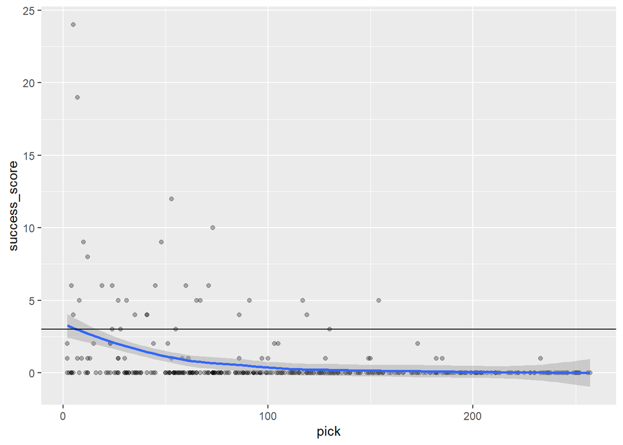

```r
rb = data %>%
  filter(position == 'RB')

ggplot(rb, aes(x = pick, y = success_score)) + geom_point(alpha = 0.3) + geom_smooth() + geom_hline(yintercept = 3)
```

```r
top50rbs = rb %>%
  filter(pick <= 50) %>%
  mutate(suc = case_when(
    success_score >= 3 ~ 'YES',
    success_score < 3 ~ 'NO'
  ))

notTop50 = rb %>%
  filter(pick > 50) %>%
  mutate(suc = case_when(
    success_score >= 3 ~ 'YES',
    success_score < 3 ~ 'NO'
  ))
```

> Clearly from this graph it shows that draft pick is a massive factor in determining how successful a running back will be in the NFL. However, unlike quarterbacks, if we narrow the sample to only to top50 running backs, we find that other factors contribute as well. In our sample, we have 360 total running backs with 31 being successful (8.6%)

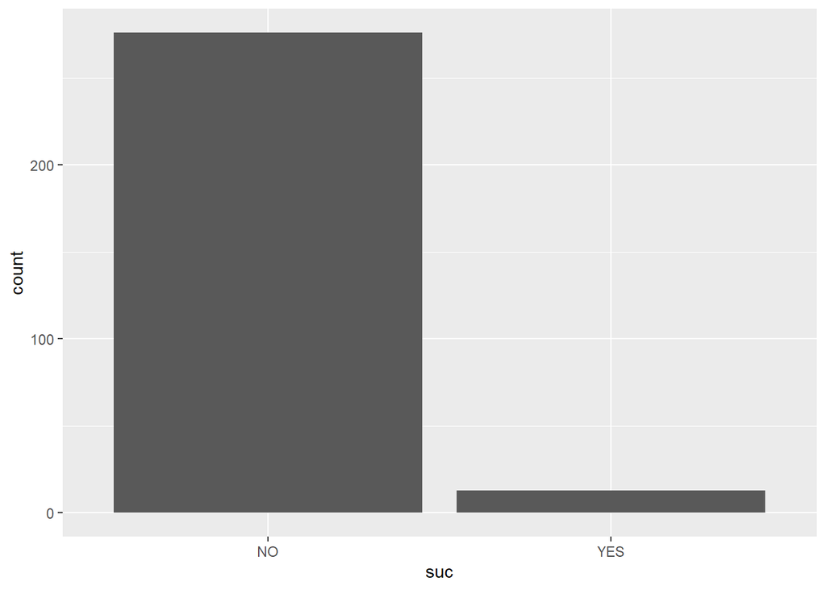

```r
ggplot(notTop50, aes(x = suc)) + geom_bar()
```

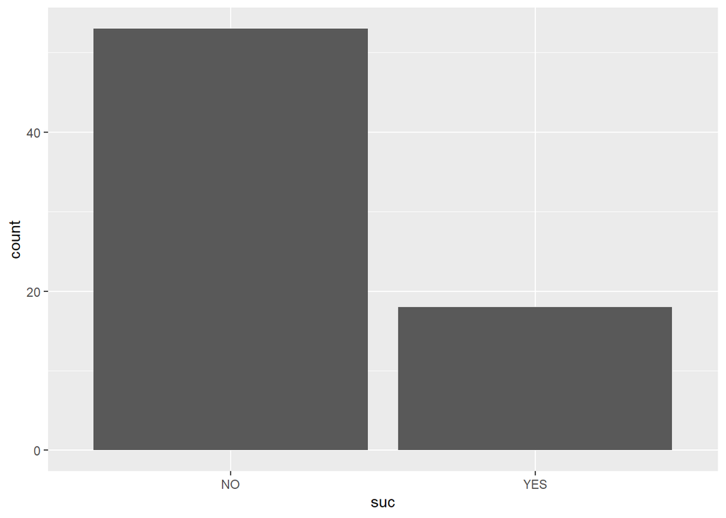

```r
ggplot(top50rbs, aes(x = suc)) + geom_bar()
```

> There are 71 running backs who were drafted top 50 and 18 were successful. Of running backs were drafted top 50, 25.3% were successful.

```r
top50rbsSpeedFit = top50rbs %>%
  filter(speed <= 4.6, speed >= 4.4) %>%
  mutate(suc = case_when(
    success_score >= 3 ~ 'YES',
    success_score < 3 ~ 'NO'
  ))

speedfit = rb %>%
  filter(speed <= 4.6, speed >= 4.4) %>%
  mutate(suc = case_when(
    success_score >= 3 ~ 'YES',
    success_score < 3 ~ 'NO'
  ))
```

> However, we can take this a step farther and show that among these top50 running backs, speed plays a huge factor.

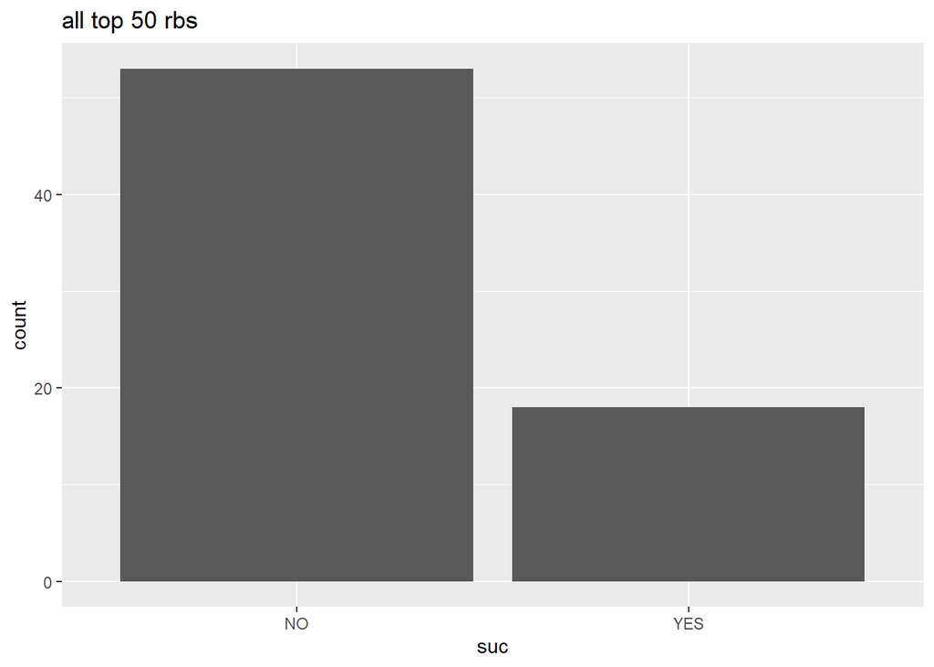

```r
ggplot(top50rbs, aes(x = suc)) + geom_bar() + ggtitle("all top 50 rbs")
```